# Auswertung TC Daten

David Lilek

06 Dezember 2022, 13:59:13

```r
# thresshold for consecutive values
TRESHHOLD <- 2
```

# 1 B - B20-B30-B40 - AF - TF

## 1.1 Plots

```r
# load libraries
library(tidyverse)
library(dplyr)
library(UpSetR)
library(pheatmap)
library(ggvenn)

############## B
data <- readRDS(file = "results_v002/results_run1_mqpar_extracts_2gether_E4_D1_B_LFQ_combined_txt_proteinGroups.txt_Unique.RDS")
data <- data[[1]]
data_sub <- dplyr::select(data, contains("Pool_G"))
#get rid of FALSE values
B <- data_sub*1
B[B==0] <- NA
ind <- apply(B, 1, function(x) all(is.na(x)))
# B total proteins
nrow(B[!ind,])
```

```
## [1] 1520
```

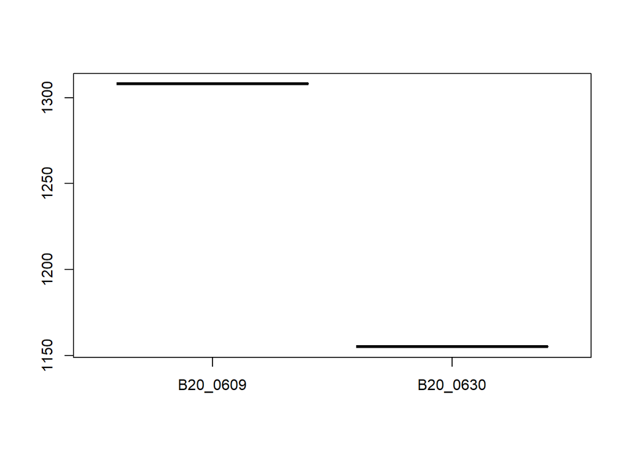

```r
# Comparison B20 (20220630) and B (20220609)
B20_0609 <- dplyr::select(data, contains("Pool_G"))
rows <- apply(B20_0609, 1, function(x)
  as.numeric(any(rle(x)$lengths >= TRESHHOLD & rle(x)$values)))
#transform 0 and 1 values to true and false
B20_0609 <- rows==1
B20_0630 <- dplyr::select(data, contains("20"))
rows <- apply(B20_0630, 1, function(x)
  as.numeric(any(rle(x)$lengths >= TRESHHOLD & rle(x)$values)))
#transform 0 and 1 values to true and false
B20_0630 <- rows==1
B20_comp <- as.data.frame(cbind(B20_0609,B20_0630))
B20_comp <- B20_comp*1
B20_comp[B20_comp==0] <- NA
# boxplot
boxplot(sum(B20_comp$B20_0609,na.rm = TRUE),
        sum(B20_comp$B20_0630,na.rm = TRUE),
        names = c("B20_0609","B20_0630"))
```

```r
### analysis B
proteins <- as.data.frame(which(!is.na(B20_comp), arr.ind=TRUE))

B20_0609 <- proteins %>% dplyr::filter(col == 1)
B20_0630 <- proteins %>% dplyr::filter(col == 2)

# combine to list
lst <- list(B20_0609 = as.double(B20_0609[,1]),
            B20_0630 = as.double(B20_0630[,1]))

upset(fromList(lst),
      order.by = "freq",
      nsets = 9,
      nintersects = 15,
      sets = c("B20_0609","B20_0630"),
      keep.order = TRUE,
      mainbar.y.label = "Number of shared proteins",
      sets.x.label = "Number of proteins per fraction",
      set_size.show = TRUE,
      set_size.angles = 0,
      set_size.scale_max = 1500
)
```

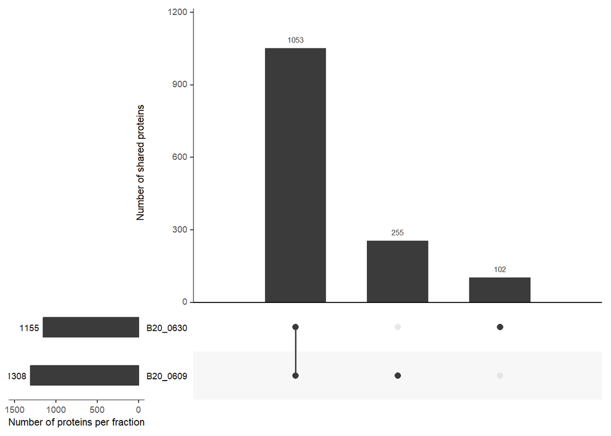

```r
############## B 20-30-40
############## B
data <- readRDS(file = "results_v002/results_run1_mqpar_extracts_2gether_E4_D1_B_MBR_LFQ_combined_txt_proteinGroups.txt_Unique.RDS")
data <- data[[1]]
B <- dplyr::select(data, contains("Pool_20"))
B20 <- B
rows <- apply(B20, 1, function(x)
  as.numeric(any(rle(x)$lengths >= TRESHHOLD & rle(x)$values)))
#transform 0 and 1 values to true and false
B20 <- rows==1
B <- dplyr::select(data, contains("Pool_30"))
B30 <- B
rows <- apply(B30, 1, function(x)
  as.numeric(any(rle(x)$lengths >= TRESHHOLD & rle(x)$values)))
#transform 0 and 1 values to true and false
B30 <- rows==1
#b40
B40 <- dplyr::select(data, contains("Pool_40"))
rows <- apply(B40, 1, function(x)
  as.numeric(any(rle(x)$lengths >= TRESHHOLD & rle(x)$values)))
#transform 0 and 1 values to true and false
B40 <- rows==1


B <- cbind(B20,B30,B40)
B <- as.data.frame(B)
B <- dplyr::select(B, contains("B"))
B <- B*1
B[B==0] <- NA

### analysis B
proteins <- as.data.frame(which(!is.na(B), arr.ind=TRUE))

B20 <- proteins %>% dplyr::filter(col == 1)
B30 <- proteins %>% dplyr::filter(col == 2)
B40 <- proteins %>% dplyr::filter(col == 3)

# combine to list
lst <- list(B20 = as.double(B20[,1]),
            B30 = as.double(B30[,1]),
            B40 = as.double(B40[,1]))

upset(fromList(lst),
      order.by = "freq",
      nsets = 9,
      nintersects = 15,
      sets = c("B20","B30","B40"),
      keep.order = TRUE,
      mainbar.y.label = "Number of shared proteins",
      sets.x.label = "Number of proteins per fraction",
      set_size.show = TRUE,
      set_size.angles = 0,
      set_size.scale_max = 1500
)
```

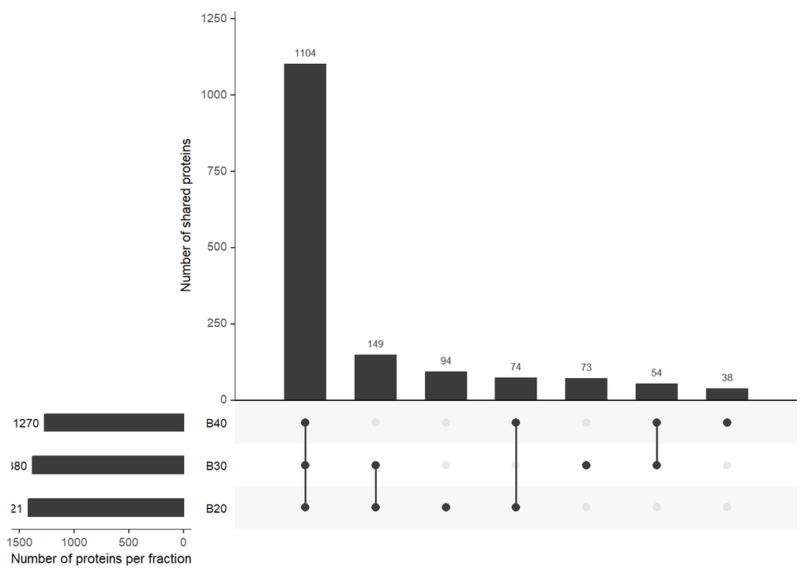

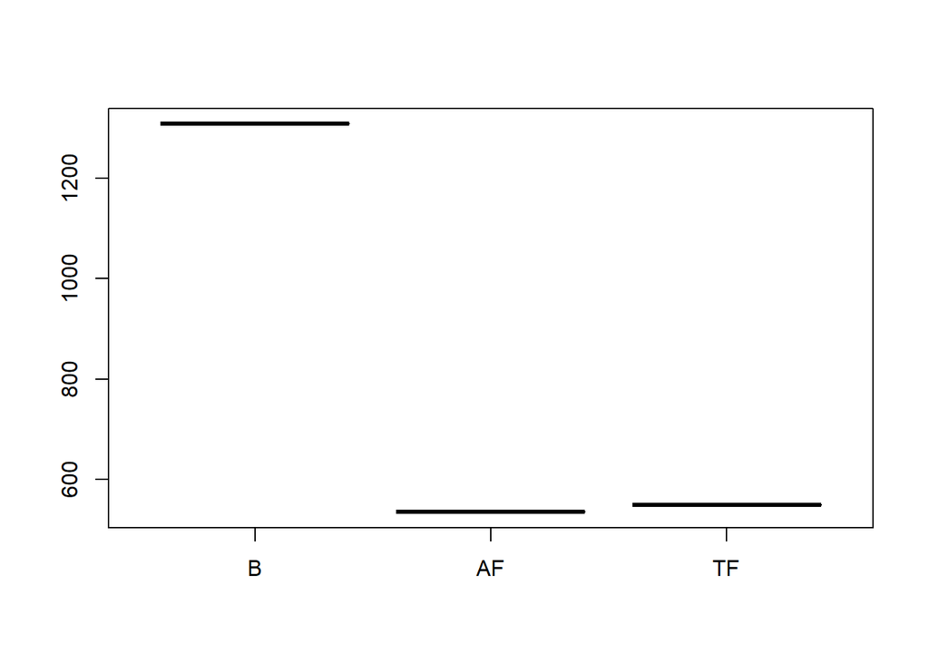

```r
## compare AF TF B poster
AF_TF_raw <- readRDS(file = "results_v002/results_run1_mqpar_extracts_2gether_E4_D1_AF_TF_LFQ_combined_txt_proteinGroups.txt_Unique.RDS")
AF_TF_raw <- AF_TF_raw[[1]]
AF <- dplyr::select(AF_TF_raw, contains("AF"))
rows <- apply(AF, 1, function(x)
  as.numeric(any(rle(x)$lengths >= TRESHHOLD & rle(x)$values)))
#transform 0 and 1 values to true and false
AF <- rows==1
AF <- as.data.frame(cbind(AF, AF_TF_raw$FASTA))
TF <- dplyr::select(AF_TF_raw, contains("TF"))
rows <- apply(TF, 1, function(x)
  as.numeric(any(rle(x)$lengths >= TRESHHOLD & rle(x)$values)))
#transform 0 and 1 values to true and false
TF <- rows==1
TF <- as.data.frame(cbind(TF, AF_TF_raw$FASTA))
B_raw <- readRDS(file = "results_v002/results_run1_mqpar_extracts_2gether_E4_D1_B_LFQ_combined_txt_proteinGroups.txt_Unique.RDS")
B_raw <- B_raw[[1]]
B <- dplyr::select(B_raw, contains("Pool_G"))
rows <- apply(B, 1, function(x)
  as.numeric(any(rle(x)$lengths >= TRESHHOLD & rle(x)$values)))
#transform 0 and 1 values to true and false
B <- rows==1
B <- as.data.frame(cbind(B, B_raw$FASTA))

AF_TF_B_comparison  <- merge(B, AF,
                           all = TRUE,
                           by = "V2")
AF_TF_B_comparison <- merge(AF_TF_B_comparison, TF,
                            all = TRUE,
                            by = "V2")

AF_TF_B_comparison$B <- as.logical(AF_TF_B_comparison$B)
AF_TF_B_comparison$AF <- as.logical(AF_TF_B_comparison$AF)
AF_TF_B_comparison$TF <- as.logical(AF_TF_B_comparison$TF)
AF_TF_B_comparison <- AF_TF_B_comparison[,-1]*1
AF_TF_B_comparison[AF_TF_B_comparison==0] <- NA

# boxplot
boxplot(sum(AF_TF_B_comparison$B,na.rm = TRUE),
        sum(AF_TF_B_comparison$AF,na.rm = TRUE),
        sum(AF_TF_B_comparison$TF,na.rm = TRUE),
        names = c("B","AF","TF"))
```

```r
proteins <- as.data.frame(which(!is.na(AF_TF_B_comparison), arr.ind=TRUE))

B <- proteins %>% dplyr::filter(col == 1)
AF <- proteins %>% dplyr::filter(col == 2)
TF <- proteins %>% dplyr::filter(col == 3)


# combine to list
lst <- list("B"=as.double(B[,1]),
            "AF"=as.double(AF[,1]),
            "TF"=as.double(TF[,1]))

upset(fromList(lst),
      order.by = "freq",
      nsets = 10,
      nintersects = 15,
      keep.order = TRUE,
      sets=c("B", "AF", "TF"),
      mainbar.y.label = "Number of shared proteins",
      sets.x.label = "Number of proteins per fraction",
      set_size.show = TRUE,
      set_size.angles = 0,
      set_size.scale_max = 1000
)
```

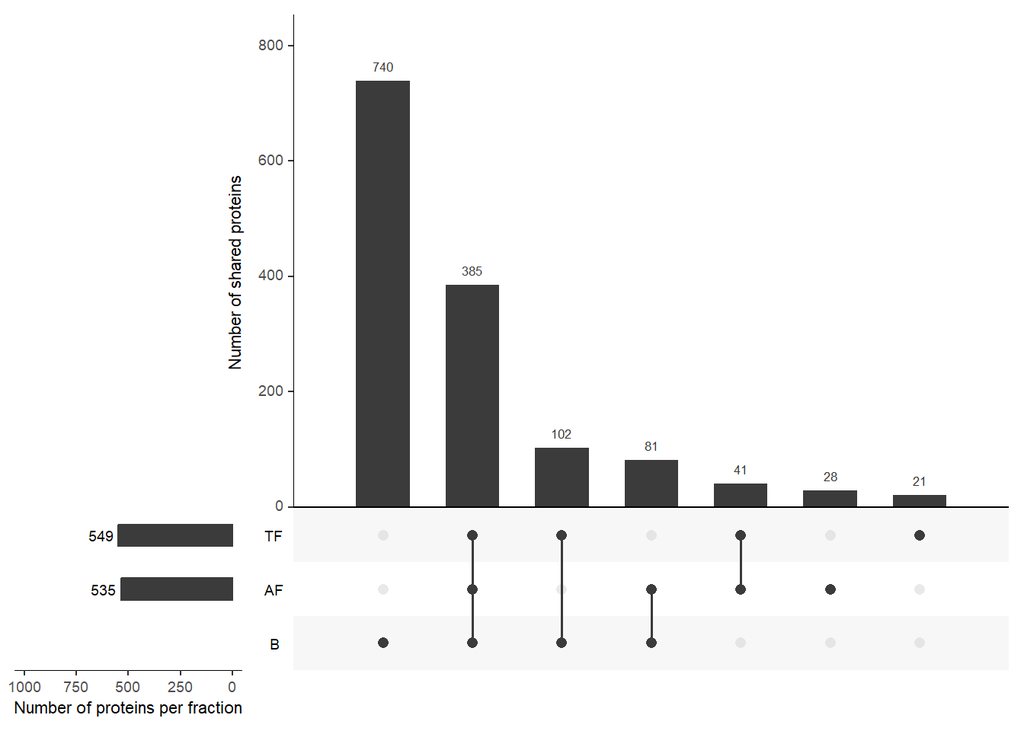

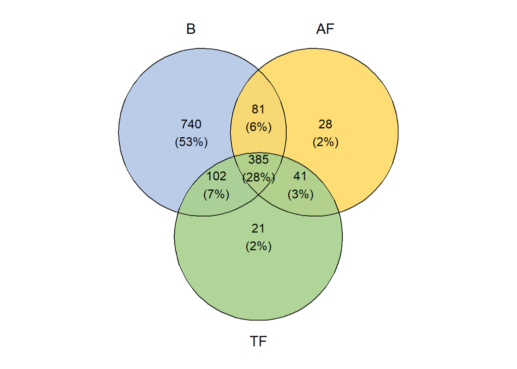

```r
#get colors
#total protein extract
total <- rgb(255,93,93, maxColorValue = 255)
#fractions high MW SEC
highMW <- rgb(169,208,142,maxColorValue = 255)
#fractions low MW SEC
lowMW <- rgb(255,217,102, maxColorValue = 255)
#in-gel digest
IG <- rgb(180,198,231,maxColorValue = 255)

ggvenn(lst,
       fill_color = c(IG,lowMW,highMW),
       stroke_size = 0.5, set_name_size = 5, text_size = 4.25, digits = 0, fill_alpha = 0.9, label_sep = )
```

```r
ggsave("./pics/unique_AF_TF_B_imputed_imputed_2consecutivevalues.png")
```

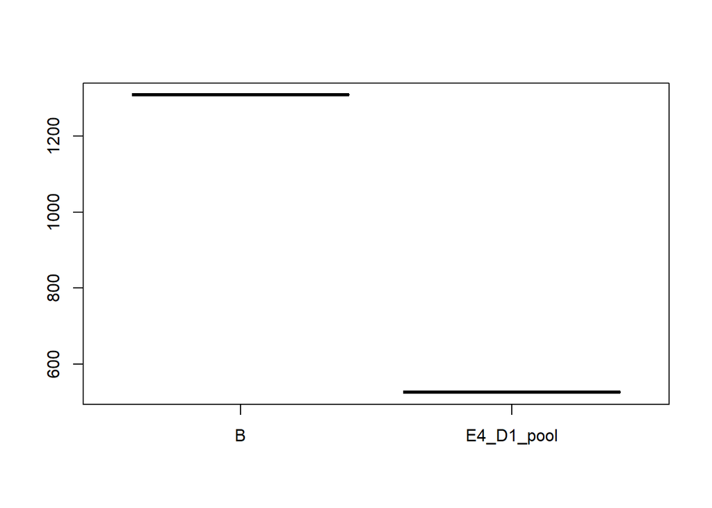

```r
#compare B to pool from 0609
B_raw <- readRDS(file = "results_v002/results_run1_mqpar_extracts_2gether_E4_D1_B_LFQ_combined_txt_proteinGroups.txt_Unique.RDS")
B_raw <- B_raw[[1]]
B <- dplyr::select(B_raw, contains("Pool_G"))
rows <- apply(B, 1, function(x)
  as.numeric(any(rle(x)$lengths >= TRESHHOLD & rle(x)$values)))
#transform 0 and 1 values to true and false
B <- rows==1
B <- as.data.frame(cbind(B, B_raw$FASTA))
aj_raw <- readRDS(file = "results_v002/results_run1_mqpar_extracts_2gether_E4_D1_a-j_LFQ_combined_txt_proteinGroups.txt_Unique.RDS")
aj_raw <- aj_raw[[1]]
aj <- dplyr::select(aj_raw, contains("Pool"))
rows <- apply(aj, 1, function(x)
  as.numeric(any(rle(x)$lengths >= TRESHHOLD & rle(x)$values)))
#transform 0 and 1 values to true and false
aj <- rows==1
aj <- as.data.frame(cbind(aj, aj_raw$FASTA))
B_aj_comparison  <- merge(B, aj,
                             all = TRUE,
                             by = "V2")

B_aj_comparison$B <- as.logical(B_aj_comparison$B)
B_aj_comparison$aj <- as.logical(B_aj_comparison$aj)
B_aj_comparison <- B_aj_comparison[,-1]*1
B_aj_comparison[B_aj_comparison==0] <- NA
boxplot(sum(B_aj_comparison$B,na.rm = TRUE),
        sum(B_aj_comparison$aj,na.rm = TRUE),
        names = c("B","E4_D1_pool"))
```

```r
proteins <- as.data.frame(which(!is.na(B_aj_comparison), arr.ind=TRUE))

B_inter <- proteins %>% dplyr::filter(col == 1)
aj_inter <- proteins %>% dplyr::filter(col == 2)

# combine to list
lst <- list("B"=as.double(B_inter[,1]),
            "E4_D1_pool"=as.double(aj_inter[,1]))

upset(fromList(lst),
      order.by = "freq",
      nsets = 10,
      nintersects = 15,
      keep.order = TRUE,
      sets=c("B", "E4_D1_pool"),
      mainbar.y.label = "Number of shared proteins",
      sets.x.label = "Number of proteins per fraction",
      set_size.show = TRUE,
      set_size.angles = 0,
      set_size.scale_max = 1000
)
```

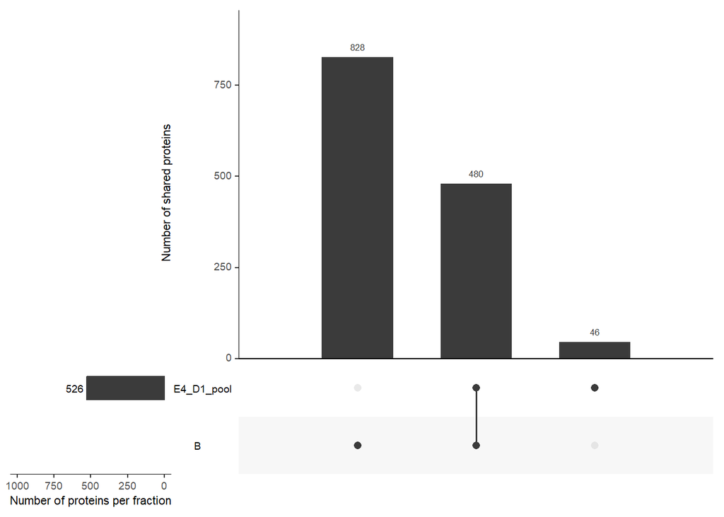

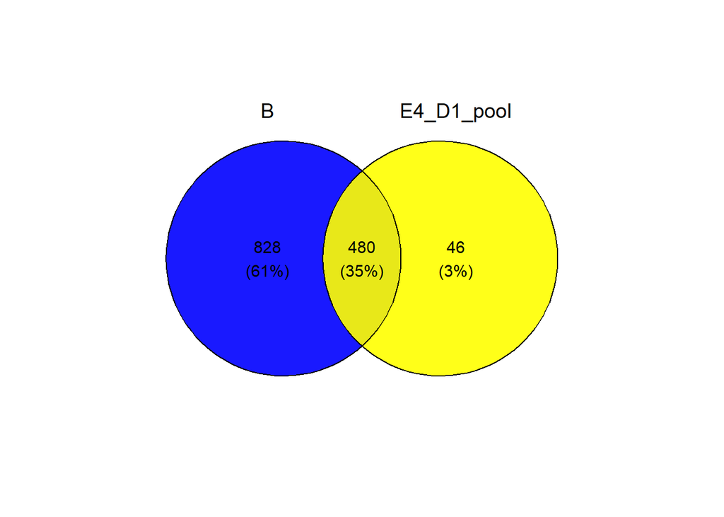

```r
ggvenn(lst,
       stroke_size = 0.5, set_name_size = 5, text_size = 4, digits = 0, fill_alpha = 0.9)
```

```r
ggsave("./pics/unique_B_D1pool_imputed_imputed_2consecutivevalues.png")
```

# 2 extract a-j with pool (0609)

## 2.1 compare a-j

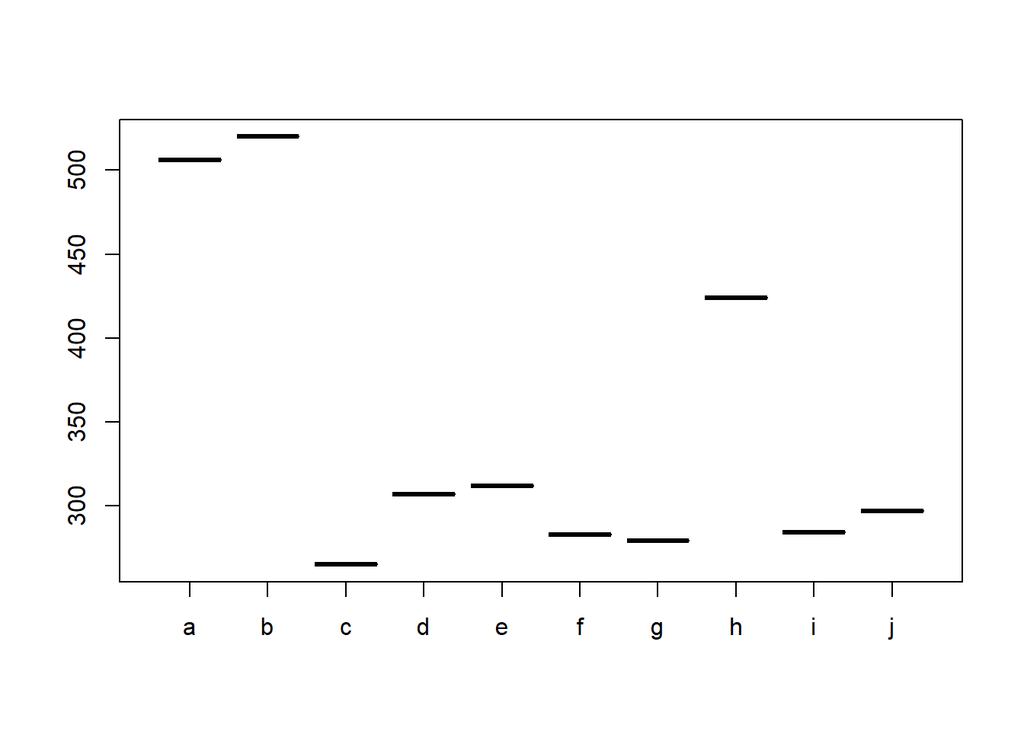

```r
## compare A-J with pool
aj_raw <- readRDS(file = "results_v002/results_run1_mqpar_extracts_2gether_E4_D1_a-j_LFQ_combined_txt_proteinGroups.txt_Unique.RDS")
aj_raw <- aj_raw[[1]]
aj <- dplyr::select(aj_raw, -contains(c("Pool","FASTA")))
aj_pool <- dplyr::select(aj_raw, contains("Pool"))

ltters <- paste("_", letters[1:10],"_", sep = "")
for (i in seq(1:10)){
  tmp <- dplyr::select(aj, contains(ltters[i]))
  #use M as selector
  rows <- apply(tmp, 1, function(x)
  as.numeric(any(rle(x)$lengths >= TRESHHOLD & rle(x)$values)))
  tmp <- tmp %>% mutate(sum = rowSums(across(where(is.logical))))
  aj[,paste(ltters[i],"M",sep="")] <- rows==1

}
aj <- dplyr::select(aj, contains(paste(ltters,"M",sep="")))
aj <- aj*1
aj[aj==0]<- NA

colnames(aj) <- letters[1:10]
sum <- as.data.frame(t(colSums(aj,na.rm = TRUE)))
boxplot(sum)
```

```r
#prepare data
proteins <- as.data.frame(which(!is.na(aj), arr.ind=TRUE))
a <- proteins %>% dplyr::filter(col == 1)
b <- proteins %>% dplyr::filter(col == 2)
c <- proteins %>% dplyr::filter(col == 3)
d <- proteins %>% dplyr::filter(col == 4)
e <- proteins %>% dplyr::filter(col == 5)
f <- proteins %>% dplyr::filter(col == 6)
g <- proteins %>% dplyr::filter(col == 7)
h <- proteins %>% dplyr::filter(col == 8)
i <- proteins %>% dplyr::filter(col == 9)
j <- proteins %>% dplyr::filter(col == 10)

# combine to list
lst <- list(a=as.double(a[,1]),
            b=as.double(b[,1]),
            c=as.double(c[,1]),
            d=as.double(d[,1]),
            e=as.double(e[,1]),
            f=as.double(f[,1]),
            g=as.double(g[,1]),
            h=as.double(h[,1]),
            i=as.double(i[,1]),
            j=as.double(j[,1]))
upset(fromList(lst),
      order.by = "freq",
      nsets = 10,
      nintersects = 15,
      keep.order = TRUE,
      sets=letters[1:10],
      mainbar.y.label = "Number of shared proteins",
      sets.x.label = "Number of proteins per fraction",
      set_size.show = TRUE,
      set_size.angles = 0,
      set_size.scale_max = 1000
)
```

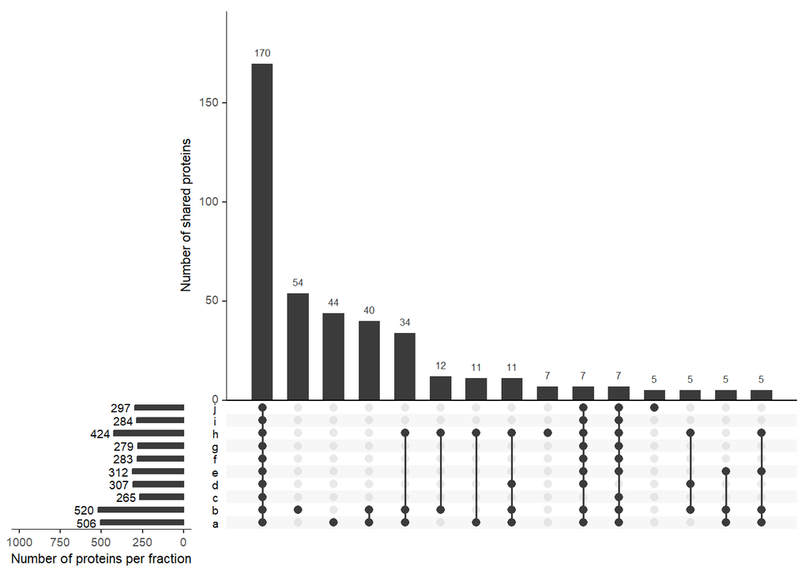

## 2.2 Compare a-j with pool

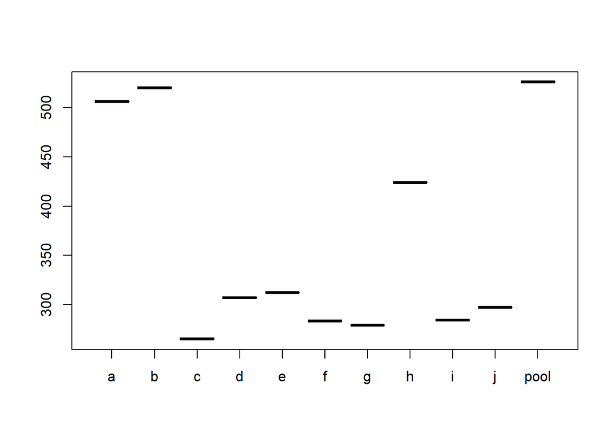

```r
# compare with pool
rows <- apply(aj_pool, 1, function(x)
  as.numeric(any(rle(x)$lengths >= TRESHHOLD & rle(x)$values)))
#transform 0 and 1 values to true and false
aj_pool <- rows==1
aj_pool <- aj_pool*1
aj_pool[aj_pool==0]<- NA

aj_pool_comp <- aj
aj_pool_comp$pool <- aj_pool

sum <- as.data.frame(t(colSums(aj_pool_comp,na.rm = TRUE)))
boxplot(sum)
```

```r
#prepare data
proteins <- as.data.frame(which(!is.na(aj_pool_comp), arr.ind=TRUE))
a <- proteins %>% dplyr::filter(col == 1)
b <- proteins %>% dplyr::filter(col == 2)
c <- proteins %>% dplyr::filter(col == 3)
d <- proteins %>% dplyr::filter(col == 4)
e <- proteins %>% dplyr::filter(col == 5)
f <- proteins %>% dplyr::filter(col == 6)
g <- proteins %>% dplyr::filter(col == 7)
h <- proteins %>% dplyr::filter(col == 8)
i <- proteins %>% dplyr::filter(col == 9)
j <- proteins %>% dplyr::filter(col == 10)
pool <- proteins %>% dplyr::filter(col == 11)

# combine to list
lst <- list(a=as.double(a[,1]),
            b=as.double(b[,1]),
            c=as.double(c[,1]),
            d=as.double(d[,1]),
            e=as.double(e[,1]),
            f=as.double(f[,1]),
            g=as.double(g[,1]),
            h=as.double(h[,1]),
            i=as.double(i[,1]),
            j=as.double(j[,1]),
            pool=as.double(pool[,1]))
upset(fromList(lst),
      order.by = "freq",
      nsets = 10,
      nintersects = 15,
      keep.order = TRUE,
      sets=c(letters[1:10],"pool"),
      mainbar.y.label = "Number of shared proteins",
      sets.x.label = "Number of proteins per fraction",
      set_size.show = TRUE,
      set_size.angles = 0,
      set_size.scale_max = 1000
)
```

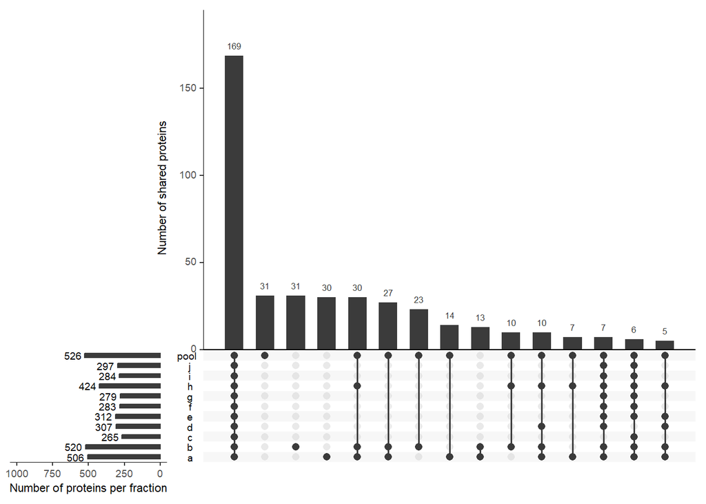

# 3 D2

```r
#############################
# D2
###############################
data <- readRDS(file = "results_v002/results_run1_mqpar_extracts_2gether_D2_LFQ_combined_txt_proteinGroups.txt_Unique.RDS")
data <- data[[1]]
data_sub <- dplyr::select(data, contains("Pool_20"))
B_D2 <- data_sub*1
B_D2[B_D2==0] <- NA


### analysis B
proteins <- as.data.frame(which(!is.na(B_D2), arr.ind=TRUE))

B1 <- proteins %>% dplyr::filter(col == 1)
B10 <- proteins %>% dplyr::filter(col == 2)
B2 <- proteins %>% dplyr::filter(col == 3)
B3 <- proteins %>% dplyr::filter(col == 4)
B4 <- proteins %>% dplyr::filter(col == 5)
B5 <- proteins %>% dplyr::filter(col == 6)
B6 <- proteins %>% dplyr::filter(col == 7)
B7 <- proteins %>% dplyr::filter(col == 8)
B8 <- proteins %>% dplyr::filter(col == 9)
B9 <- proteins %>% dplyr::filter(col == 10)
# combine to list
lst <- list(B1 = as.double(B1[,1]),
            B2 = as.double(B2[,1]),
            B3 = as.double(B3[,1]),
            B4 = as.double(B4[,1]),
            B5 = as.double(B5[,1]),
            B6 = as.double(B6[,1]),
            B7 = as.double(B7[,1]),
            B8 = as.double(B8[,1]),
            B9 = as.double(B9[,1]),
            B10 = as.double(B10[,1]))

upset(fromList(lst),
      order.by = "freq",
      nsets = 9,
      nintersects = 15,
      sets = c("B1","B2","B3","B4","B5","B6","B7","B8","B9","B10"),
      keep.order = TRUE,
      mainbar.y.label = "Number of shared proteins",
      sets.x.label = "Number of proteins per fraction",
      set_size.show = TRUE,
      set_size.angles = 0,
      set_size.scale_max = 1000
)
```

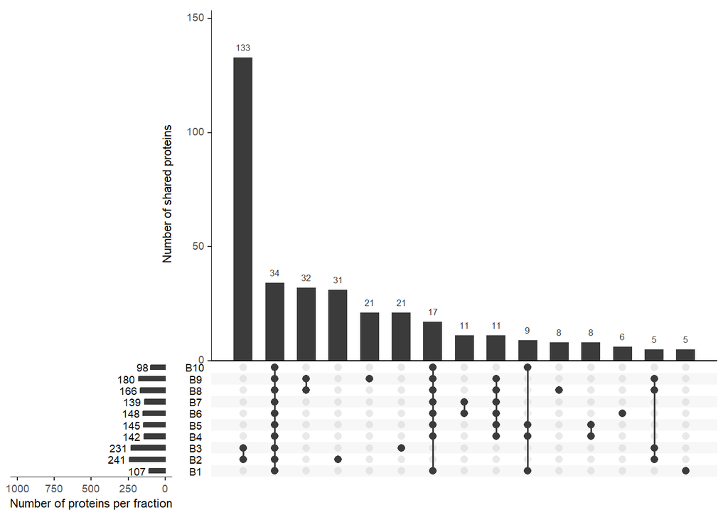

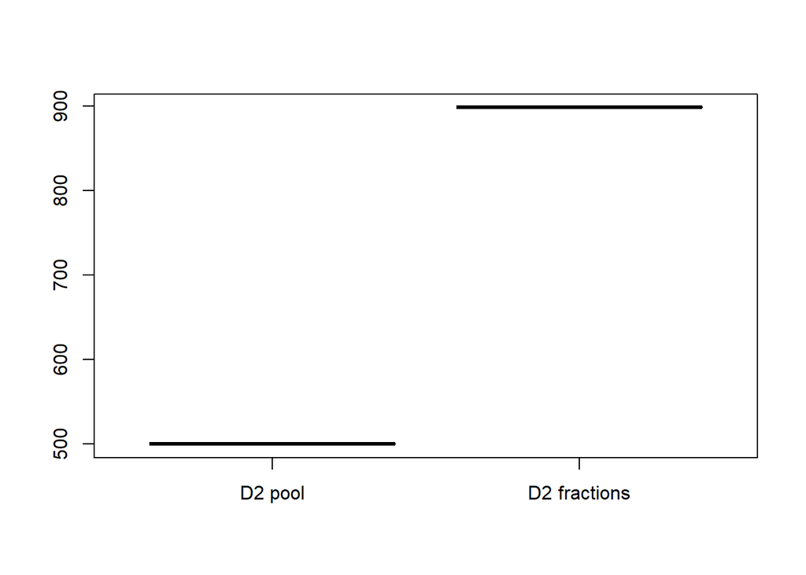

```r
data_D2_pool <- dplyr::select(data, contains("Gesamt"))
rows <- apply(data_D2_pool, 1, function(x)
  as.numeric(any(rle(x)$lengths >= TRESHHOLD & rle(x)$values)))
#transform 0 and 1 values to true and false
data_D2_pool <- rows==1
data_D2_fractions <- dplyr::select(data, contains("20"))
data_D2_fractions <- data_D2_fractions[,c(1,2,5:20,3,4)]
rows <- apply(data_D2_fractions, 1, function(x)
  as.numeric(any(rle(x)$lengths >= TRESHHOLD & rle(x)$values)))
#transform 0 and 1 values to true and false
data_D2_fractions <- rows==1
data_D2 <- as.data.frame(cbind(data_D2_pool,data_D2_fractions))
data_D2 <- data_D2*1
data_D2[data_D2==0] <- NA
# boxplot
boxplot(sum(data_D2$data_D2_pool,na.rm = TRUE),
        sum(data_D2$data_D2_fractions,na.rm = TRUE),
        names = c("D2 pool","D2 fractions"))
```

```r
proteins <- as.data.frame(which(!is.na(data_D2), arr.ind=TRUE))

D2_pool_inter <- proteins %>% dplyr::filter(col == 1)
D2_fractions_inter <- proteins %>% dplyr::filter(col == 2)

# combine to list
lst <- list(D2_pool=as.double(D2_pool_inter[,1]),
            D2_fractions=as.double(D2_fractions_inter[,1]))

upset(fromList(lst),
      order.by = "freq",
      nsets = 10,
      nintersects = 15,
      keep.order = TRUE,
      sets=c("D2_pool", "D2_fractions"),
      mainbar.y.label = "Number of shared proteins",
      sets.x.label = "Number of proteins per fraction",
      set_size.show = TRUE,
      set_size.angles = 0,
      set_size.scale_max = 1000
)
```

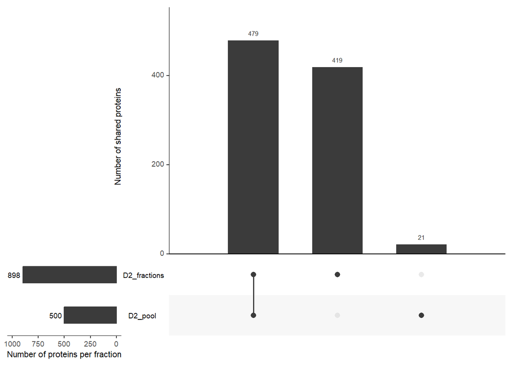

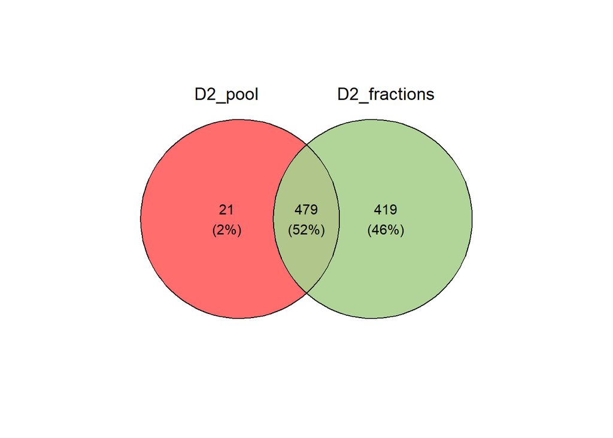

```r
#venn digarams
#get colors
D2_pool_col <- rgb(255,93,93, maxColorValue = 255)
D2_ingel_col <- rgb(169,208,142,maxColorValue = 255)
#E4_D1_pool_col <- rgb(255,217,102, maxColorValue = 255)

ggvenn(lst,
       fill_color = c(D2_pool_col,D2_ingel_col),
       stroke_size = 0.5, set_name_size = 5, text_size = 4, digits = 0, fill_alpha = 0.9)
```

```r
ggsave("./pics/unique_D2__imputed_2consecutivevalues.png")
```

# 4 Compare D1-D2

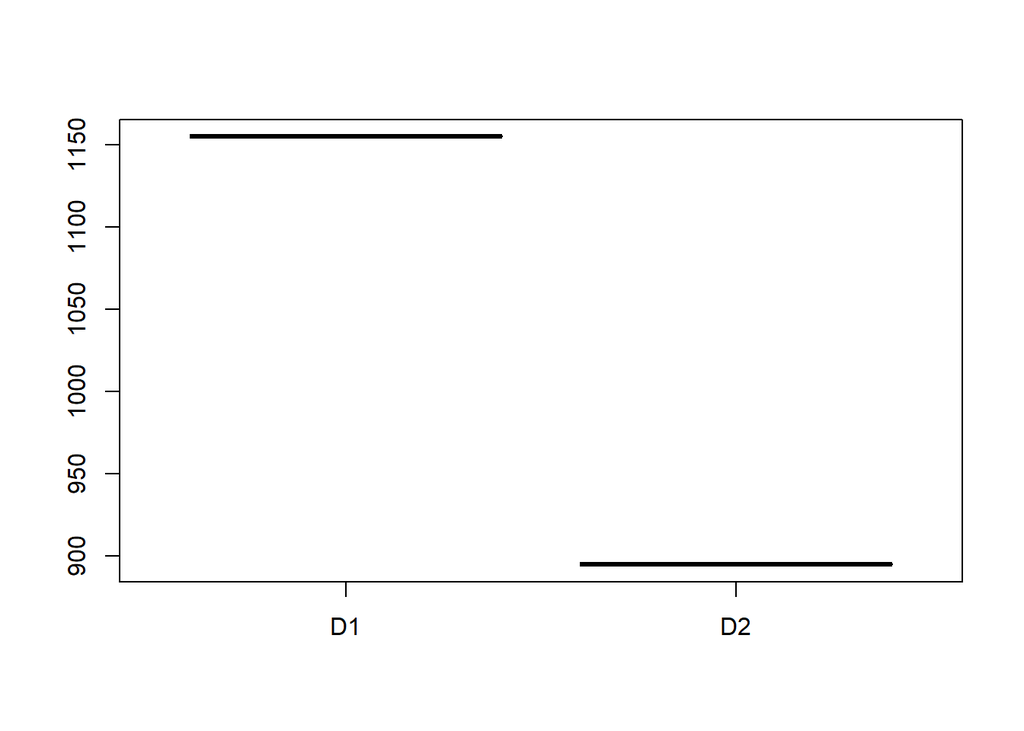

```r
# D1-D2 comparison

D1_raw <- readRDS(file = "results_v002/results_run1_mqpar_extracts_2gether_E4_D1_B_LFQ_combined_txt_proteinGroups.txt_Unique.RDS")
D1_raw <- D1_raw[[1]]
D1 <- dplyr::select(D1_raw, contains("20"))
rows <- apply(D1, 1, function(x)
  as.numeric(any(rle(x)$lengths >= TRESHHOLD & rle(x)$values)))
#transform 0 and 1 values to true and false
D1 <- rows==1
D1 <- as.data.frame(cbind(D1, D1_raw$FASTA))
D2_raw <- readRDS(file = "results_v002/results_run1_mqpar_extracts_2gether_D2_LFQ_combined_txt_proteinGroups.txt_Unique.RDS")
D2_raw <- D2_raw[[1]]
D2 <- dplyr::select(D2_raw, contains("Pool_20"))
rows <- apply(D2, 1, function(x)
  as.numeric(any(rle(x)$lengths >= TRESHHOLD & rle(x)$values)))
#transform 0 and 1 values to true and false
D2 <- rows==1
D2 <- as.data.frame(cbind(D2, D2_raw$FASTA))
D1_D2_comparison  <- merge(D1, D2,
                           all = TRUE,
                           by = "V2")

D1_D2_comparison$D1 <- as.logical(D1_D2_comparison$D1)
D1_D2_comparison$D2 <- as.logical(D1_D2_comparison$D2)
D1_D2_comparison <- D1_D2_comparison[,-1]*1
D1_D2_comparison[D1_D2_comparison==0] <- NA

# boxplot
boxplot(sum(D1_D2_comparison$D1,na.rm = TRUE),
        sum(D1_D2_comparison$D2,na.rm = TRUE),
        names = c("D1","D2"))
```

```r
proteins <- as.data.frame(which(!is.na(D1_D2_comparison), arr.ind=TRUE))

D1_inter <- proteins %>% dplyr::filter(col == 1)
D2_inter <- proteins %>% dplyr::filter(col == 2)

# combine to list
lst <- list("D1\ningeldigest_pool"=as.double(D1_inter[,1]),
            "D2\ningeldigest_pool"=as.double(D2_inter[,1]))

upset(fromList(lst),
      order.by = "freq",
      nsets = 10,
      nintersects = 15,
      keep.order = TRUE,
      sets=c("D1\ningeldigest_pool", "D2\ningeldigest_pool"),
      mainbar.y.label = "Number of shared proteins",
      sets.x.label = "Number of proteins per fraction",
      set_size.show = TRUE,
      set_size.angles = 0,
      set_size.scale_max = 1000
)
```

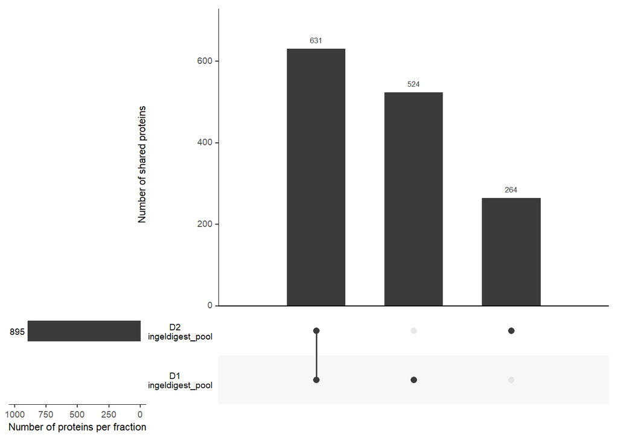

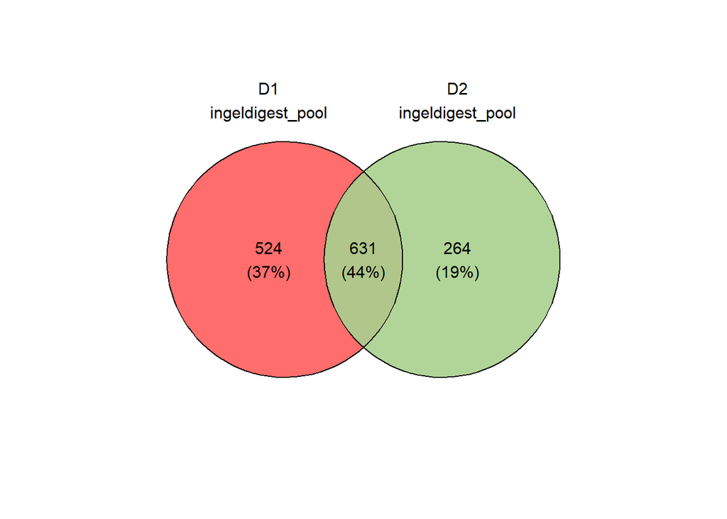

```r
#venn digarams
#get colors
D1_col <- rgb(255,93,93, maxColorValue = 255)
D2_col <- rgb(169,208,142,maxColorValue = 255)
#E4_D1_pool_col <- rgb(255,217,102, maxColorValue = 255)

ggvenn(lst,
       fill_color = c(D1_col,D2_col),
       stroke_size = 0.5, set_name_size = 4, text_size = 4, digits = 0, fill_alpha = 0.9)
```

```r
ggsave("./pics/unique_D1_D2_imputed_imputed_2consecutivevalues.png")
```

# 5 Besprechen/todo

- nehmen wir LFQ oder die identifizierten Proteine?
- nehmen wir razor oder unique? ich würde fast razor nehmen, weil ja ohnehin zu der proteingruppe zugeordnet wird die am wahrscheinlichsten ist
- wie poolen wir? zB B1_1, B1_2, B2_1, B2_2…
  - wenn ich dort alle Proteine zähle führt es ev. zu einem Überbefund?
  - wäre es nicht besser B1_1 und B1_2 -> nur wenn Protein in beiden vorkommt ist es auch da? weil ja technische replikate also 2x gemessen oder?
  - wenn 2 biologische replikate; also 2x extrahiert würde ich es so machen, dass ich auch sagen es ist da wenn es nur in einem Extrakt vorkommt | also zB B1_1 TRUE - B1_2 FALSE
- was gehört überhaupt gepooled und verglichen? können wir uns das bitte noch anschauen?
- was gehört bei D2 gepooled und verglichen?
- man könnte ja Razor nehmen und im paper bezug nehmen, dass ergebnisse ähnlich wie unique
- zusätzlich noch anschauen mit LFQ? wieviele proteine von den identifzierten sind überhaupt quantifizierbar? das könnte man auch ins paper geben, dass wenn man lfq nimmt man mit ca. 20-25%(also je nachdem was dann rauskommt) rechnen muss? weil ja später dann bei differential expression analysis ja auch quantifizierte proteine verwendet werden; also meistens halt